# Analyzing baseball Data with R

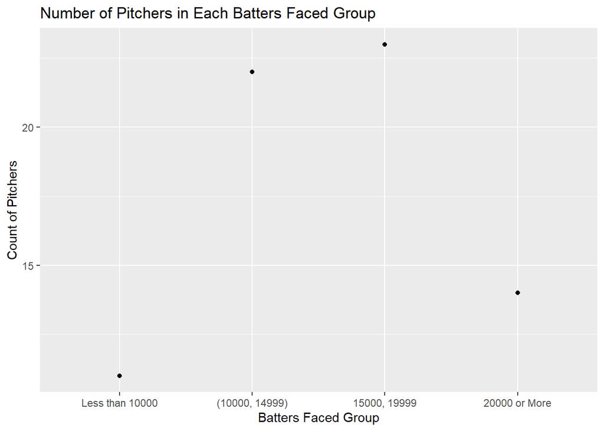

```r
ggsave("HOFPitchingBarChart.png")
ggplot(hofpitching_bfgroupfreqtable, aes(BF.group, Frequency)) +
  geom_point() +
  ylab("Count of Pitchers") +
  xlab("Batters Faced Group") +
  ggtitle("Number of Pitchers in Each Batters Faced Group")
```

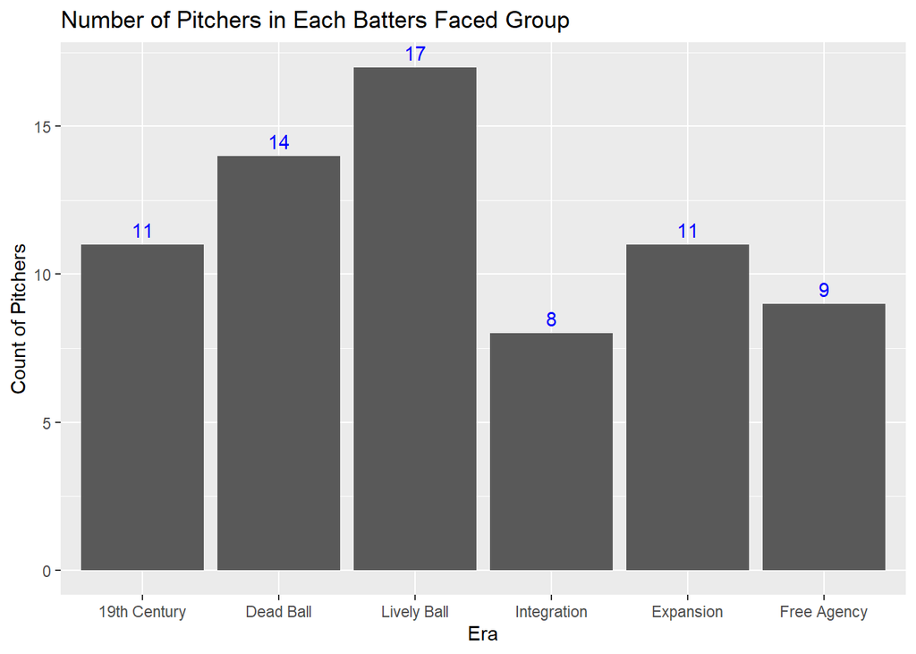

```r
ggsave("HOFPitchingdotplot.png")
ggplot(hofpitching, aes(Era)) +
  geom_bar() +
  geom_text(stat = "count", aes(label = after_stat(count), vjust=-0.5), color="blue") +
  ylab("Count of Pitchers") +
  xlab("Era") +
  ggtitle("Number of Pitchers in Each Batters Faced Group")
```

```r
  ggsave("HOFPitchingbyeya.png")
```

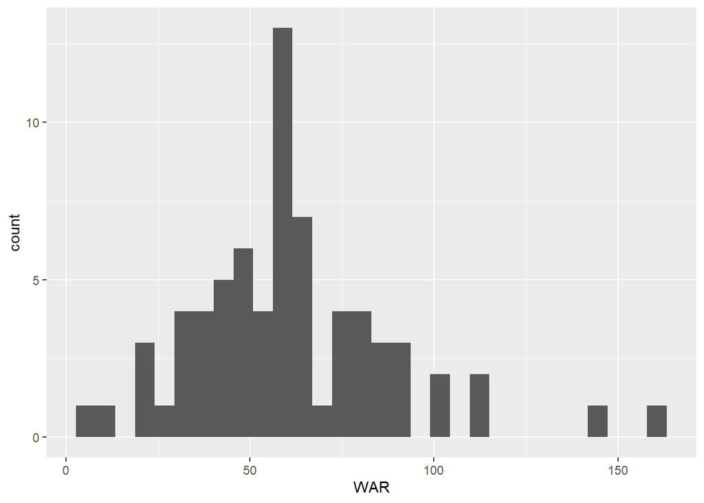

```r
ggplot(hofpitching, aes(WAR)) +
  geom_histogram()
```

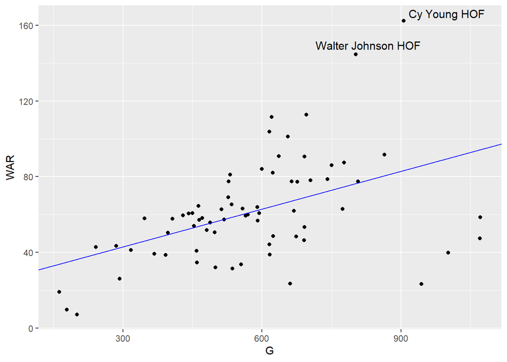

```r
linear_model <- lm(WAR ~ G, data=hofpitching)

ggplot(hofpitching, aes(G, WAR)) +
  geom_point() +
  geom_text_repel(
    data = subset(hofpitching, WAR > quantile(WAR, 0.75) + 1.5 * IQR(WAR) | WAR < quantile(WAR, 0.25) - 1.5 * IQR(WAR)),
  aes(x = G, y = WAR, label = X),
  color = "#000000",
  size = 4,
  nudge_x = 0.2, nudge_y = 0.4,
  segment.color = "red") +
  geom_abline(intercept=coef(linear_model)[1], slope = coef(linear_model)[2], color = "blue")
```

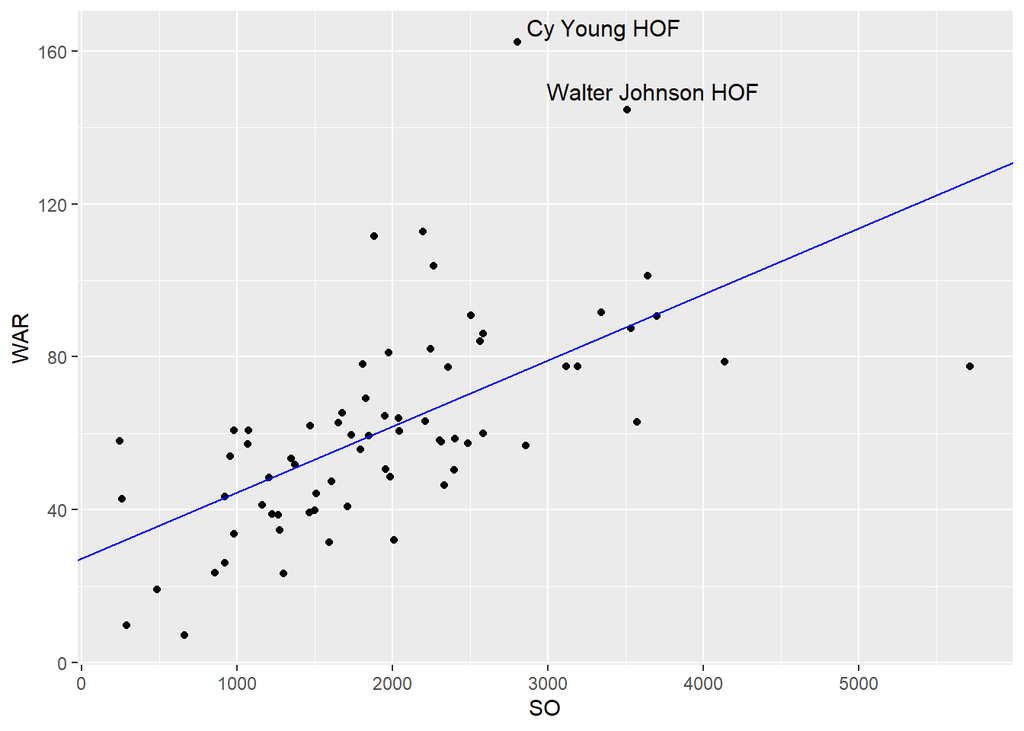

```r
linear_model2 <- lm(WAR ~ SO, data=hofpitching)

ggplot(hofpitching, aes(SO, WAR)) +
  geom_point() +
  geom_text_repel(
    data = subset(hofpitching, WAR > quantile(WAR, 0.75) + 1.5 * IQR(WAR) | WAR < quantile(WAR, 0.25) - 1.5 * IQR(WAR)),
  aes(x = SO, y = WAR, label = X),
  color = "#000000",
  size = 4,
  nudge_x = 0.2, nudge_y = 0.4,
  segment.color = "red") +
  geom_abline(intercept=coef(linear_model2)[1], slope = coef(linear_model2)[2], color = "blue")
```

Create a variable which shows WAR per season

```r
hofpitching <- hofpitching %>%
  mutate(WAR.season = WAR/Yrs)
```

Let’s graph

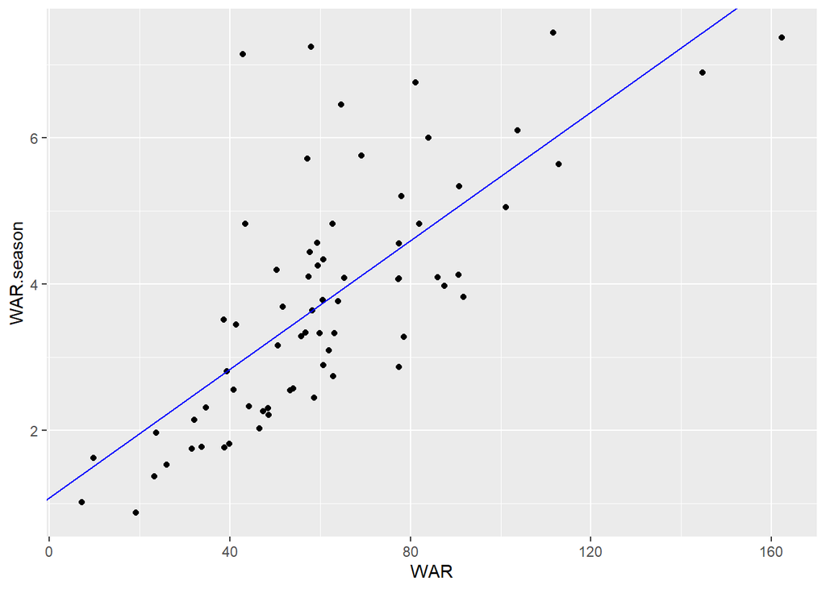

```r
linear_model2 <- lm(WAR.season ~ WAR, data=hofpitching)

ggplot(hofpitching, aes(WAR, WAR.season)) +
  geom_point() +
  geom_text_repel(
    data = subset(hofpitching, WAR.season > quantile(WAR.season, 0.75) + 1.5 * IQR(WAR.season) | WAR.season < quantile(WAR.season, 0.25) - 1.5 * IQR(WAR.season)),
  aes(x = WAR, y = WAR.season, label = X),
  color = "#000000",
  size = 4,
  nudge_x = 0.2, nudge_y = 0.4,
  segment.color = "red") +
  geom_abline(intercept=coef(linear_model2)[1], slope = coef(linear_model2)[2], color = "blue")
```

[output not shown]

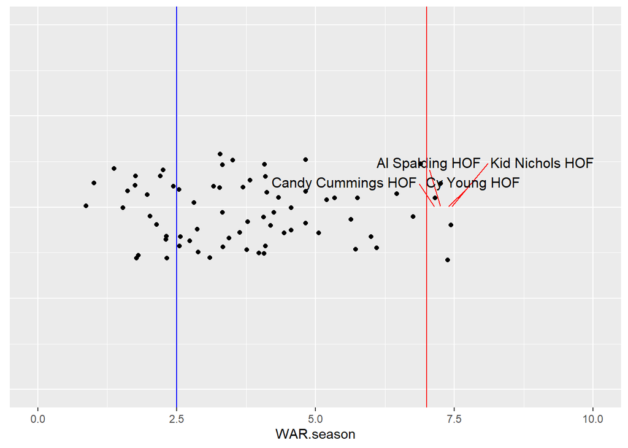

```r
ggplot(hofpitching, aes(WAR.season, y=1)) +
  geom_jitter(height = 0.6) + ylim(-1,3) +
  theme(axis.title.y = element_blank(),
        axis.text.y = element_blank(),
        axis.ticks.y = element_blank()) +
  coord_fixed(ratio = 0.03) +
  geom_text_repel(
    data = subset(hofpitching, WAR.season > 7 | WAR.season < 2.5),
  aes(x = WAR.season, y = 1, label = X),
  color = "#000000",
  size = 4,
  nudge_x = 0.2, nudge_y = 0.4,
  segment.color = "red") +
  geom_vline(xintercept=7, color="red") +
  geom_vline(xintercept=2.5, color = "blue") +
  coord_cartesian(xlim = c(0,10))
```

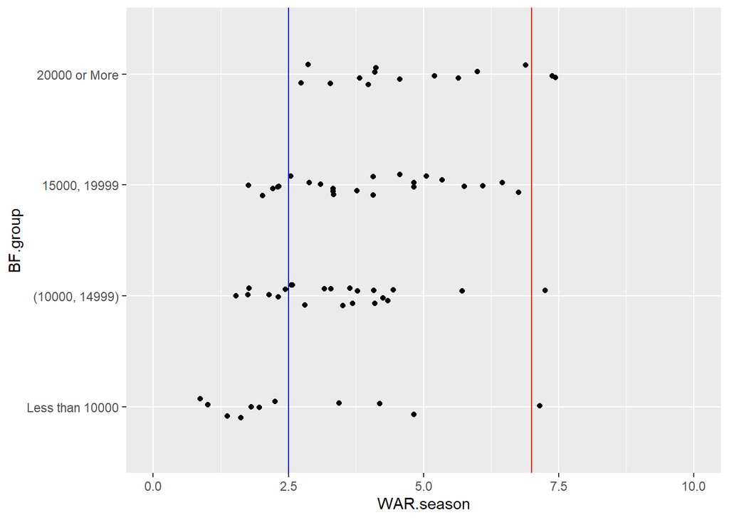

```r
ggplot(hofpitching, aes(WAR.season, BF.group)) +
  geom_jitter(height = 0.1) +
  geom_vline(xintercept=7, color="red") +
  geom_vline(xintercept=2.5, color = "blue") +
  coord_cartesian(xlim = c(0,10))
```

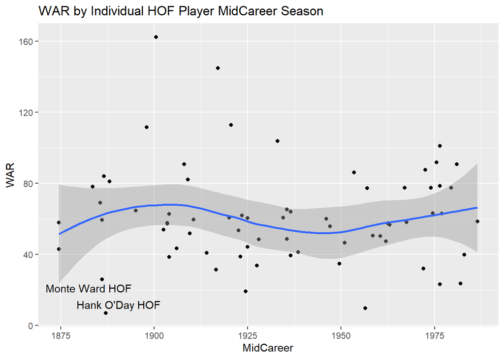

```r
ggplot(hofpitching, aes(MidCareer, WAR)) +
  geom_point() +
  geom_smooth() +
  ggtitle("WAR by Individual HOF Player MidCareer Season") +
  geom_text_repel(
    data = subset(hofpitching, WAR.season < 1.75 & MidCareer <1900) ,
    aes(x=MidCareer, y=WAR, label=X)
  )
```

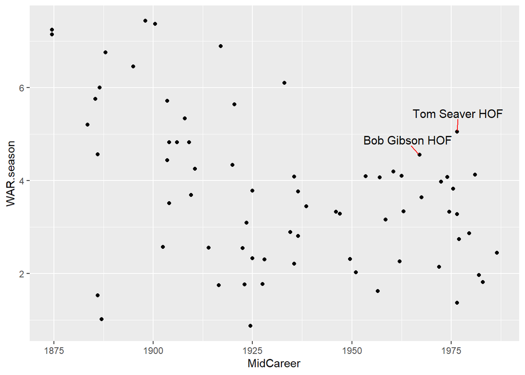

```r
hofpitching <- hofpitching %>%
  arrange(MidCareer)

hofpitching.recent <- hofpitching
ggplot(hofpitching, aes(MidCareer, WAR.season)) +
  geom_point() +
  geom_text_repel(
    data = subset(hofpitching, WAR.season > 4.2 & MidCareer >1959),
  aes(x = MidCareer, y = WAR.season, label = X),
  color = "#000000",
  size = 4,
  nudge_x = 0.2, nudge_y = 0.4,
  segment.color = "red")
```

Exercise 3.6 Working with the Lahman Batting Dataset

1. Read in the Lahman Master and Batting Data Frames (this was already done above)
2. Collect in a single data frame the season batting statistics for the great hitters ty Cobb, Ted Williams, and Pete Rose

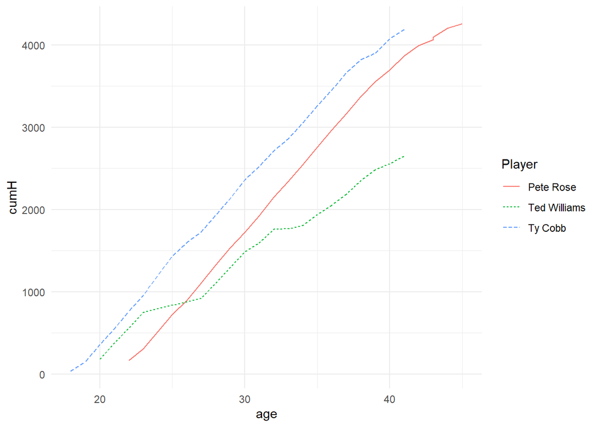

```r
#Batting %>%
#  inner_join(PlayerInfo, by="playerID") %>%
#  mutate(Age = yearID - birthyear) %>%
#  select(Player, Age, HR) %>%
#  group_by(Player)%>%
#  mutate(CHR = cumsum(HR)) -> HRdata

get_player_id <- function(player_name) {
  Names <- unlist(strsplit(player_name, " "))
  Master %>%
    filter(nameFirst == Names[1],
           nameLast == Names[2]) %>%
    mutate(birthyear = ifelse(birthMonth >= 7,
                              birthYear+1, birthYear),
           Player =  paste(nameFirst, nameLast)) %>%
    select(playerID, Player, birthyear, height, weight, bats, throws, birthCountry, birthState, birthCity)
}

TedWilliams_PeteRose_TyCobb_Info <- bind_rows(get_player_id("Ted Williams"),
                                              get_player_id("Pete Rose"),
                                              get_player_id("Ty Cobb"))

TedWilliams_PeteRose_TyCobb_Info <- TedWilliams_PeteRose_TyCobb_Info %>%
  filter(playerID != "rosepe02")

Batting_TC_PR_TW <-  Batting %>%
  inner_join(TedWilliams_PeteRose_TyCobb_Info, by="playerID") %>%
  mutate(age = yearID - birthyear) %>%
  group_by(Player) %>%
  arrange(Player, yearID) %>%
  mutate(cumH = cumsum(H)) -> Hdata

Pete_Rose_Lineplot <- ggplot(Hdata, aes(x=age, y=cumH, linetype=Player)) +
  geom_line(aes(colour=Player)) +
  theme_minimal()

print(Pete_Rose_Lineplot)
```

As you can see from the above graph, Ted Williams’ starting accumulating hits after Ty Cobb (around the age 20 season). However, there were large periods of stagnation resulting in him finishing with significantly less hits than Pete Rose and Ty Cobb. The slope of the line however, appears to be similar in his first two periods before stagnation. The eriods of stagnation are seasons Ted did not play, because he was in the war. It may be reasonable to project a similar slope to his line as Pete and Ty, however, we do see a change in the slope of the line in his 30s and beyond. It’s tough to project what would have happened had he not been absent from the game.

Pete Rose and Ty Cobb had similar slopes, meaning they acucmulated hits at a similar rate. However, Ty Cobb achieved 4000 hits before his age 40 season, whereas Pete Rose accumlated 4000 after his age 40 season. However, since the slopes are very similar, we notice that this is largely due to Pete beginning to accumulate hits later in his career (after age 20) than Ty Cobb (stated. before age 20).